# Bayesian data analysis

## Overview

This file walks you through the process of building and running a Bayesian statistical model using R. There are many reasons why you might want to adopt the Bayesian framework over the null hypothesis testing (NHT) framework, but for one of my projects, I decided to try the Bayesian analysis for the following reasons:

- **The project was set out to test for null effect.** Under the NHT framework, a p-value of > 0.05 cannot mean that the null hypothesis is correct. In contrast, if a Bayes Factor (used to compare posterior probabilities of different hypotheses) is above a certain threshold, that can actually be interpreted as more direct evidence for the null.
- **Dependent variable was multinomial (=more than two levels).** My DV was a participant’s responses of either “Yes”, “No”, or “I don’t know.” There are many packages for multinomial regression, but I found the Bayesian one (with `BRMS` package) to be the easiest for fitting more elaborate models and has fewer convergence issues.

## Load packages

You will need the following packages for conducting Bayesian analysis.

- `brms` for constructing models
- `bayestestR` for computing Bayes Factor

## Load data

```r
data = read.csv("./bayesian_tutorial.csv")
```

```r
glimpse(data)
```

```
## Rows: 513
## Columns: 5
## $ Participant.ID <int> 1, 1, 1, 1, 1, 1, 1, 1, 1, 2, 2, 2, 2, 2, 2, 2, 2, 2, 3…
## $ List           <int> 1, 1, 1, 1, 1, 1, 1, 1, 1, 2, 2, 2, 2, 2, 2, 2, 2, 2, 1…
## $ quantifier     <chr> "all", "some", "some", "some", "all", "some", "some", "…
## $ fruit          <chr> "banana", "orange", "apple", "banana", "orange", "banan…
## $ response       <chr> "Y", "Y", "I", "N", "Y", "I", "N", "I", "Y", "Y", "N", …
```

We’re using a fake dataset with the following variables (columns):

Here’s a plot summarizing the data.

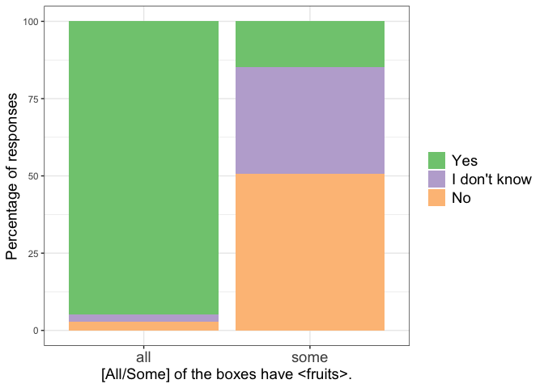

We will treat `quantifier` as an independent variable (with `Participant.ID` and `fruit` as random effects) and build a model to see whether the type of quantifier used in the experimenter’s utterance (“some” or “all”) affected the participants’ responses.

## Conduct a Bayesian analysis

### Set priors

The first step in a Bayesian analysis is setting priors, which are my initial beliefs or knowledge about the parameters before observing the data. If you don’t have strong beliefs about the parameters, you should set priors that are weakly informative - priors that have only a small influence on the posterior distribution. In other words, setting weakly informative priors means that you’re allowing your data to strongly influence the posterior distribution.

We are setting weakly informative priors (Student’s t-distribution for intercept, normal distribution for others) for this analysis. You can do so with the `prior` function.

**Note**: In the code below, I needed to specify the `dpar` parameter (name of a distributional parameter) in addition to the `class` parameter, or otherwise I would get the error “The following priors do not correspond to any model parameter” - even though classes “Intercept” and “b” do exist. I don’t know how common it is (or if it’s necessary) to specify the `dpar` parameter, and would greatly appreciate any suggestions to set alternative ways to set priors!

```r
priors = c(
  set_prior("student_t(3, 0, 2.5)", class = "Intercept", dpar = "muN"),
  set_prior("student_t(3, 0, 2.5)", class = "Intercept", dpar = "muY"),
  set_prior("normal(0, 8)", class = "b", coef = "quantifiersome", dpar = "muN"),
  set_prior("normal(0, 8)", class = "b", coef = "quantifiersome", dpar = "muY")
)
```

### Build a model

Using the priors from above, here’s how to write a model. I set the three parameters (`chains`, `iter`, `warmup`) manually, but you can also leave them blank and default values apply. Here’s what those parameters do:

- `chains`: Number of independent Markov Chain Monte Carlo (MCMC) chains (sequences of parameter values generated by the Markov chain during the simulation)
- `iter`: Number of iterations for each chain, including warm-up and sampling phases.
- `warmup`: Number of iterations used for warm-up. Samples drawn during this phase are typically discarded, and only the samples from the actual sampling phase are used for inference.

```r
model = brm(response ~ quantifier + (1|Participant.ID) + (1|fruit), data=data,
           family="categorical", chains=3, iter=3000, warmup=600,
           prior = priors,
           save_all_pars = TRUE)
```

[output not shown]

```r
summary(model)
```

```
##  Family: categorical
##   Links: muN = logit; muY = logit
## Formula: response ~ quantifier + (1 | Participant.ID) + (1 | fruit)
##    Data: data (Number of observations: 513)
##   Draws: 3 chains, each with iter = 3000; warmup = 600; thin = 1;
##          total post-warmup draws = 7200
##
## Group-Level Effects:
## ~fruit (Number of levels: 3)
##                   Estimate Est.Error l-95% CI u-95% CI Rhat Bulk_ESS Tail_ESS
## sd(muN_Intercept)     0.69      0.95     0.01     4.11 1.05       67       31
## sd(muY_Intercept)     0.45      0.55     0.02     2.01 1.02      241     2216
##
## ~Participant.ID (Number of levels: 57)
##                   Estimate Est.Error l-95% CI u-95% CI Rhat Bulk_ESS Tail_ESS
## sd(muN_Intercept)     1.31      0.25     0.87     1.83 1.03      107      369
## sd(muY_Intercept)     1.51      0.29     0.97     2.14 1.01     1685     2468
##
## Population-Level Effects:
##                    Estimate Est.Error l-95% CI u-95% CI Rhat Bulk_ESS Tail_ESS
## muN_Intercept          0.31      1.13    -1.54     3.05 1.05       52       14
## muY_Intercept          4.75      0.73     3.42     6.25 1.02      163      183
## muN_quantifiersome     0.33      0.75    -1.10     1.83 1.02      257      581
## muY_quantifiersome    -6.01      0.71    -7.39    -4.72 1.02      143      198
##
## Draws were sampled using sampling(NUTS). For each parameter, Bulk_ESS
## and Tail_ESS are effective sample size measures, and Rhat is the potential
## scale reduction factor on split chains (at convergence, Rhat = 1).
```

We can change priors to make them more informative, like the following:

```r
alt_priors = c(
  set_prior("beta(4, 8)", class = "Intercept", dpar = "muN"),
  set_prior("student_t(3, 0, 2.5)", class = "Intercept", dpar = "muY"),
  set_prior("beta(4, 8)", class = "b", coef = "quantifiersome", dpar = "muN"),
  set_prior("normal(0, 8)", class = "b", coef = "quantifiersome", dpar = "muY")
)
```

### Obtain Bayes factors

For hypothesis testing (is the use of different quantifiers lead to different patterns of response?) under the Bayesian framework, we can compare the posterior probabilities of different hypotheses by means of Bayes factor (BF). More specifically, you can evaluate the likelihood of the data under H1 that quantifier makes a difference to the likelihood of the data under H0 that it doesn’t make a difference. The threshold for whether H0 or H1 is more likely is arbitrary, just like p-value under the NHT framework. For this tutorial, we adopt the following thresholds by Jeffreys (1939/1961):

- BF > 3: Strong evidence for H1
- BF < 0.33: Strong evidence for H0
- BF between 0.33 and 3: Indecisive (data supports neither H1 nor H0)

You can obtain the Bayes Factor of your variables with the `bayesfactor_parameters` function.

```r
bayesfactor_parameters(model, null = 0)
```

```
## Bayes Factor (Savage-Dickey density ratio)
##
## Parameter          |       BF
## -----------------------------
## muN_Intercept      |    0.146
## muY_Intercept      | 1.49e+05
## muN_quantifiersome |    0.092
## muY_quantifiersome | 2.66e+11
##
## * Evidence Against The Null: 0
```

To see the overall effect of the independent variable (quantifier used), we can also compare the model we created with an intercept-only model, just like how we compare multiple linear models with anova.

```r
m0 = brm(response ~ 1, # intercept only model
          data=data,
          family="categorical", chains=3, iter=3000, warmup=600,
          save_all_pars = TRUE)
```

[output not shown]

```r
comparison = bayesfactor_models(model, denominator = m0)
comparison
```

```
## Bayes Factors for Model Comparison
##
##     Model                                                 BF
## [1] quantifier + (1 | Participant.ID) + (1 | fruit) 7.40e+78
##
## * Against Denominator: [2] (Intercept only)
## *   Bayes Factor Type: marginal likelihoods (bridgesampling)
```

The BF turned out to be a very large number, which is in support of H1 - the use of quantifier does affect the pattern of responses.

That’s it! I very much appreciate the feedback - if you notice any mistakes, please get in touch.

## Reference

Jeffreys, Harold. 1939/1961. Theory of probability. Oxford: Oxford University Press.